# Project3.1

# Wine Quality Reds:-

In these project we are discussing about Red wine contains 13 variables of 1599 observations, first changing the directory to our file location as follows.

Installing and loading the files required to complete the project.

# UNIVARIATE PLOTS:-

we are going to explore the data using each variable to get clear view about the variables and applying the statistical methods to find the relations between them. The summary is the overview of the each variable.

```
##        X          fixed.acidity   volatile.acidity  citric.acid
##  Min.   :   1.0   Min.   : 4.60   Min.   :0.1200   Min.   :0.000
##  1st Qu.: 400.5   1st Qu.: 7.10   1st Qu.:0.3900   1st Qu.:0.090
##  Median : 800.0   Median : 7.90   Median :0.5200   Median :0.260
##  Mean   : 800.0   Mean   : 8.32   Mean   :0.5278   Mean   :0.271
##  3rd Qu.:1199.5   3rd Qu.: 9.20   3rd Qu.:0.6400   3rd Qu.:0.420
##  Max.   :1599.0   Max.   :15.90   Max.   :1.5800   Max.   :1.000
##  residual.sugar     chlorides       free.sulfur.dioxide
##  Min.   : 0.900   Min.   :0.01200   Min.   : 1.00
##  1st Qu.: 1.900   1st Qu.:0.07000   1st Qu.: 7.00
##  Median : 2.200   Median :0.07900   Median :14.00
##  Mean   : 2.539   Mean   :0.08747   Mean   :15.87
##  3rd Qu.: 2.600   3rd Qu.:0.09000   3rd Qu.:21.00
##  Max.   :15.500   Max.   :0.61100   Max.   :72.00
##  total.sulfur.dioxide    density             pH          sulphates
##  Min.   :  6.00       Min.   :0.9901   Min.   :2.740   Min.   :0.3300
##  1st Qu.: 22.00       1st Qu.:0.9956   1st Qu.:3.210   1st Qu.:0.5500
##  Median : 38.00       Median :0.9968   Median :3.310   Median :0.6200
##  Mean   : 46.47       Mean   :0.9967   Mean   :3.311   Mean   :0.6581
##  3rd Qu.: 62.00       3rd Qu.:0.9978   3rd Qu.:3.400   3rd Qu.:0.7300
##  Max.   :289.00       Max.   :1.0037   Max.   :4.010   Max.   :2.0000
##     alcohol         quality
##  Min.   : 8.40   Min.   :3.000
##  1st Qu.: 9.50   1st Qu.:5.000
##  Median :10.20   Median :6.000
##  Mean   :10.42   Mean   :5.636
##  3rd Qu.:11.10   3rd Qu.:6.000
##  Max.   :14.90   Max.   :8.000
```

```
## 'data.frame':    1599 obs. of  13 variables:
##  $ X                   : int  1 2 3 4 5 6 7 8 9 10 ...
##  $ fixed.acidity       : num  7.4 7.8 7.8 11.2 7.4 7.4 7.9 7.3 7.8 7.5 ...
##  $ volatile.acidity    : num  0.7 0.88 0.76 0.28 0.7 0.66 0.6 0.65 0.58 0.5 ...
##  $ citric.acid         : num  0 0 0.04 0.56 0 0 0.06 0 0.02 0.36 ...
##  $ residual.sugar      : num  1.9 2.6 2.3 1.9 1.9 1.8 1.6 1.2 2 6.1 ...
##  $ chlorides           : num  0.076 0.098 0.092 0.075 0.076 0.075 0.069 0.065 0.073 0.071 ...
##  $ free.sulfur.dioxide : num  11 25 15 17 11 13 15 15 9 17 ...
##  $ total.sulfur.dioxide: num  34 67 54 60 34 40 59 21 18 102 ...
##  $ density             : num  0.998 0.997 0.997 0.998 0.998 ...
##  $ pH                  : num  3.51 3.2 3.26 3.16 3.51 3.51 3.3 3.39 3.36 3.35 ...
##  $ sulphates           : num  0.56 0.68 0.65 0.58 0.56 0.56 0.46 0.47 0.57 0.8 ...
##  $ alcohol             : num  9.4 9.8 9.8 9.8 9.4 9.4 9.4 10 9.5 10.5 ...
##  $ quality             : int  5 5 5 6 5 5 5 7 7 5 ...
```

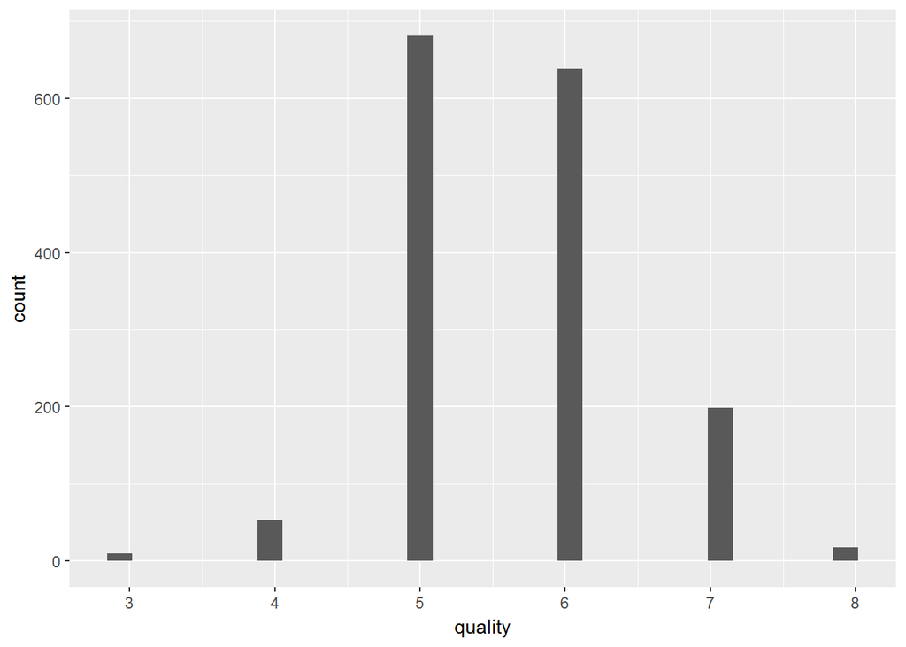

In the above plot it is showing that in given observation there are very less amount of low and high quality wines are given.Now lets see the another plot

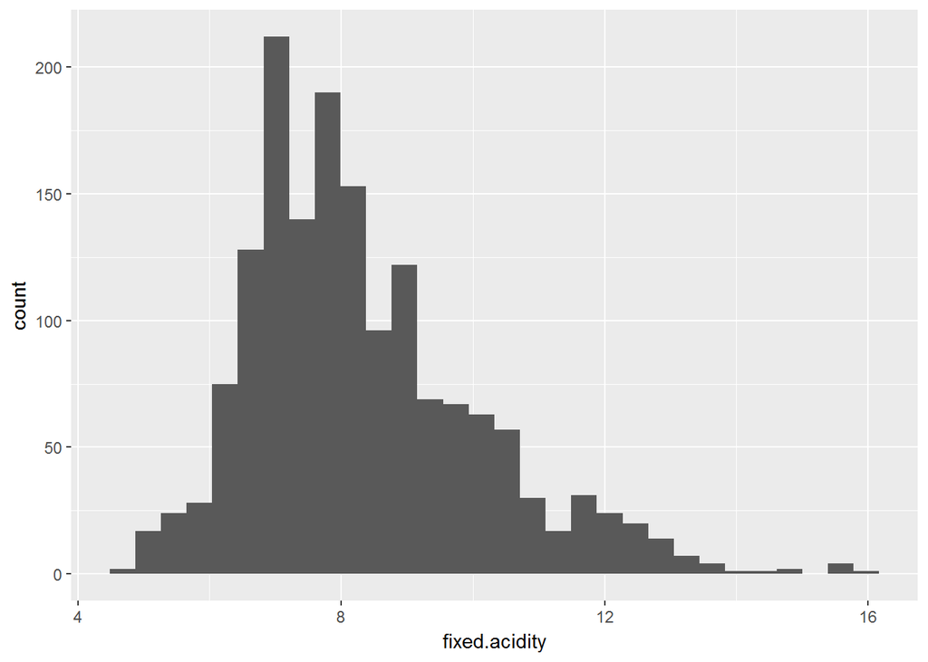

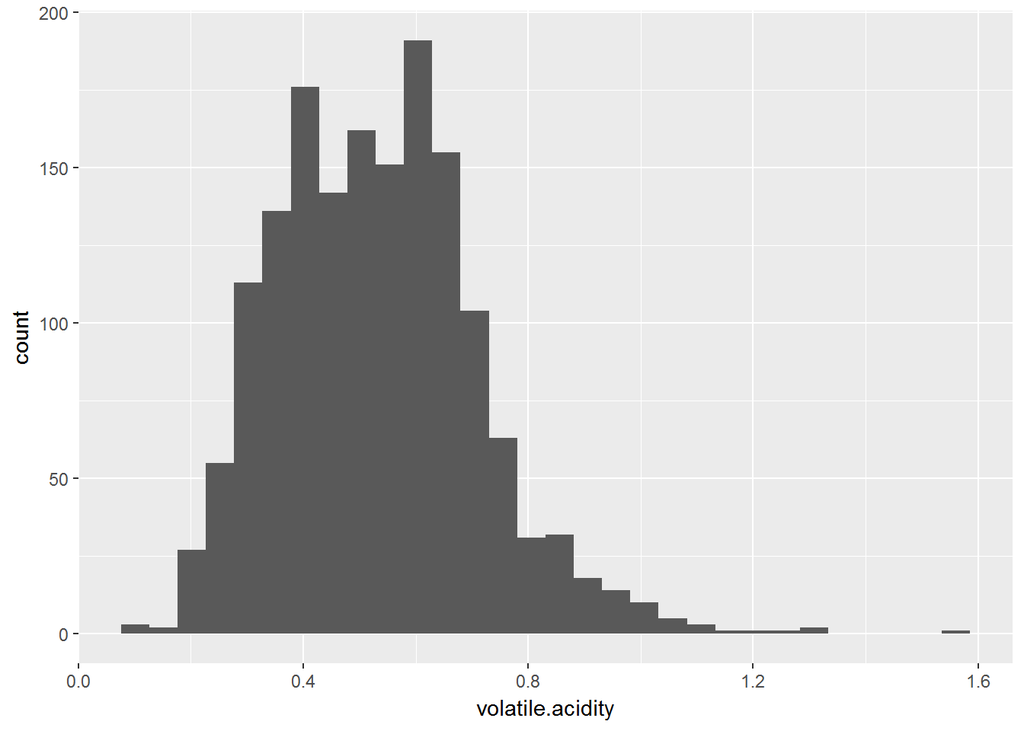

comparing to the fixed acidity the volatile acidity concentration is very less and appers to be bimodal with high range of outliers

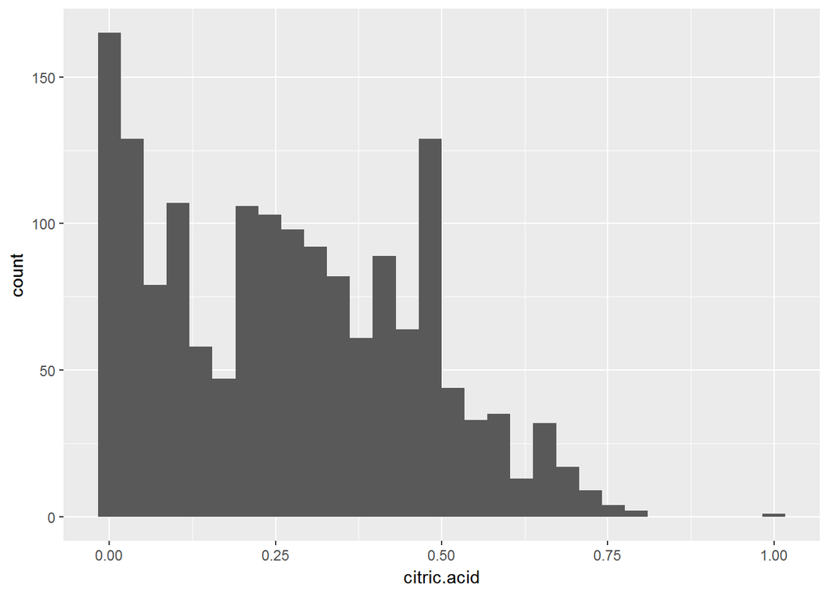

It is seem to be very intreasting plot and the concentration level is very less compare to the other acidic variables.

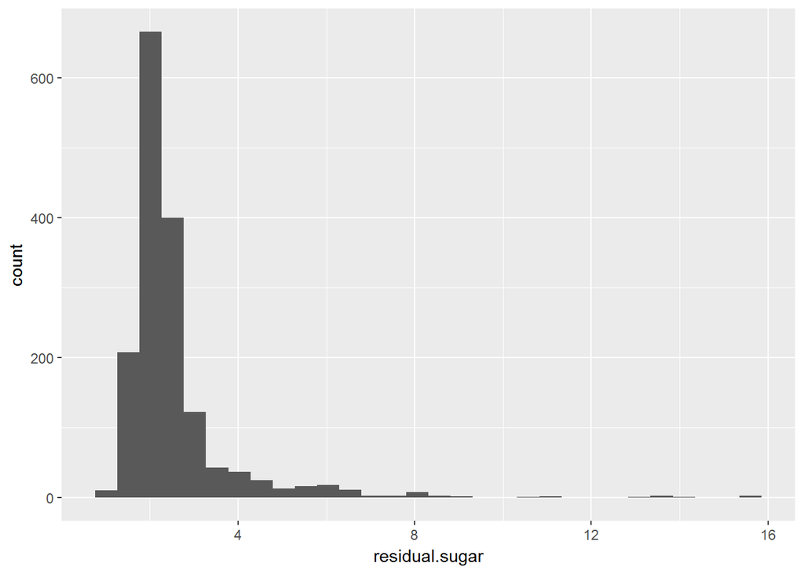

The median is nearby 2 which mostly used for the high quality wines.

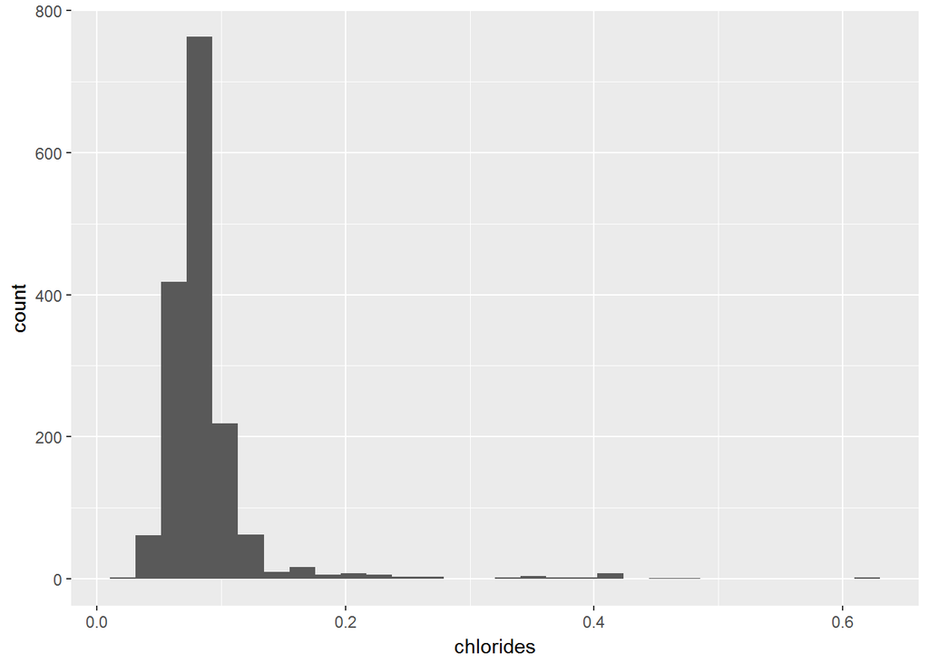

It is very interesting that the chlorides have similar distribuation to residual sugar level in in the wine but the meadian and mean changes by values.

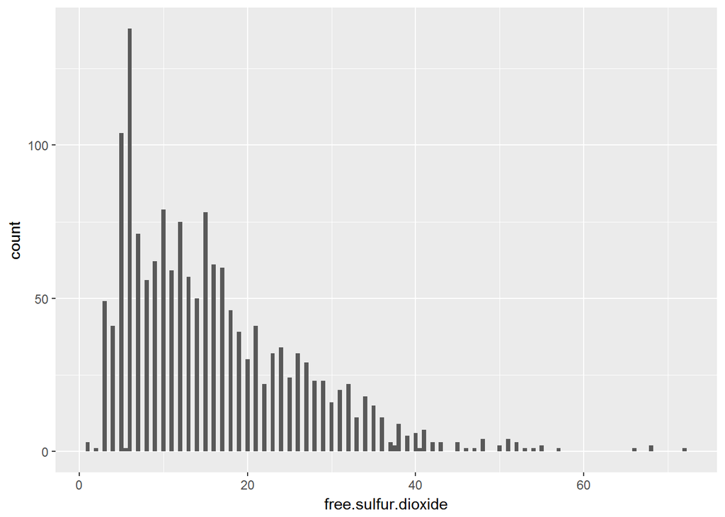

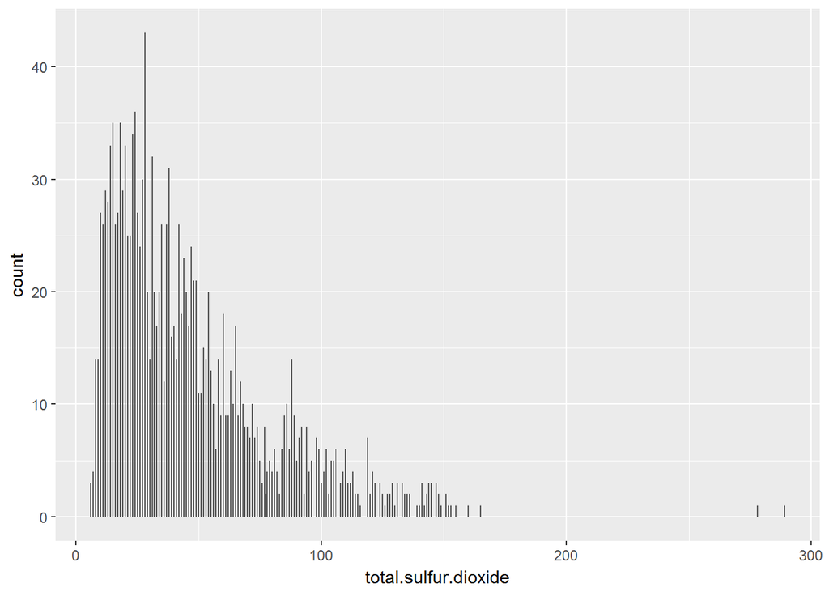

The mean is 46 and median is 38 and which is similar to the free sulfur dioxide.

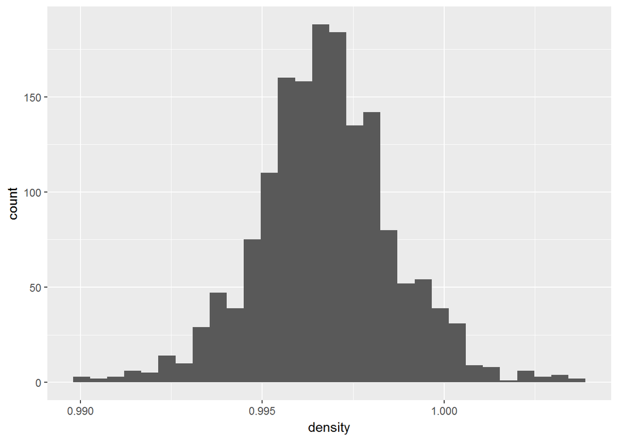

Density is seem to be noramlly distributed.

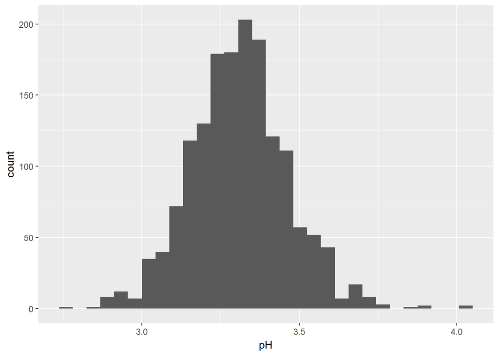

The Density and the PH value are having similar normal distributions.

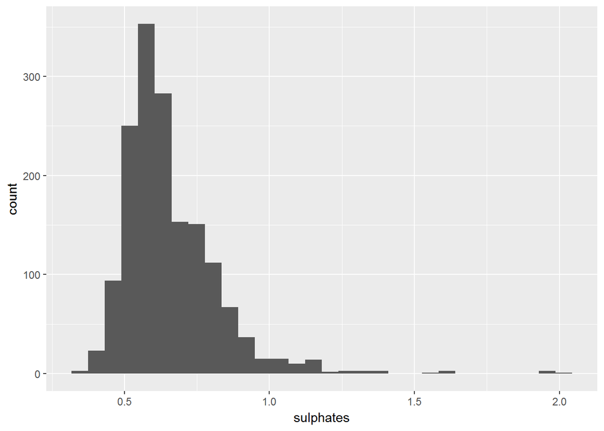

The above distribaution is similar to the sugar varibale in the data.

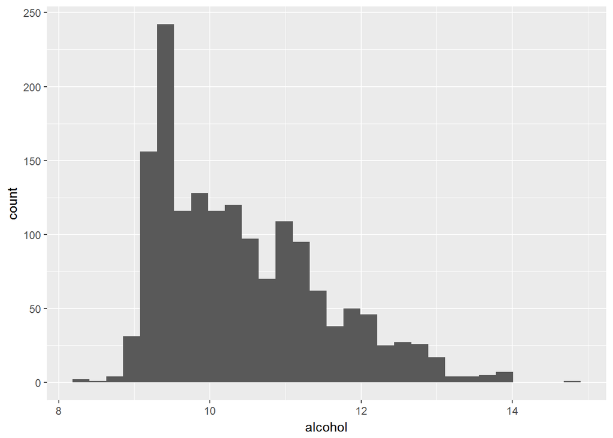

It is having rapid growth in the distribution and here some the variables are having similar distribution.

# UNIVARIATE ANALYSIS: -

**What is the th structure of yor dataset?**

The data consists of 1599 observations with 12 different variables, Here the quality of a wine is denoted by the scale 0-10 were 0 is bad and 10 is good with there alcohol % by volume and the pH is a logarithemic value, density is calculated with (g/cm^3) and all other variables are with (mg/dm^3).

**What is/are the main feature(s) of interest in your dataset?**

The volatile acidity,sulphates,citric acidity,alcohol,chlorides are the interesting variables and the distributions between the variables are different with the quality and quality is one of the important variable in the data set.

**Did you create any new variable fro existing variablesin the datset?**

**Of the features you investigated, were there any unusaualdistributions? Did you perform any operations on the data to tidy, adjust, or change the form of the data?is so, why did you do this?**

Among all those variables citric acid has a unusual distribution.Which has the values of wines are 1 mg/dm^3.

# BIVARIATE PLOTS SECTION: -

**CORRELATION BETWEEN VARIABLES SHOWN IN THE PLOTS**

**Exploring the factors with density of wine**

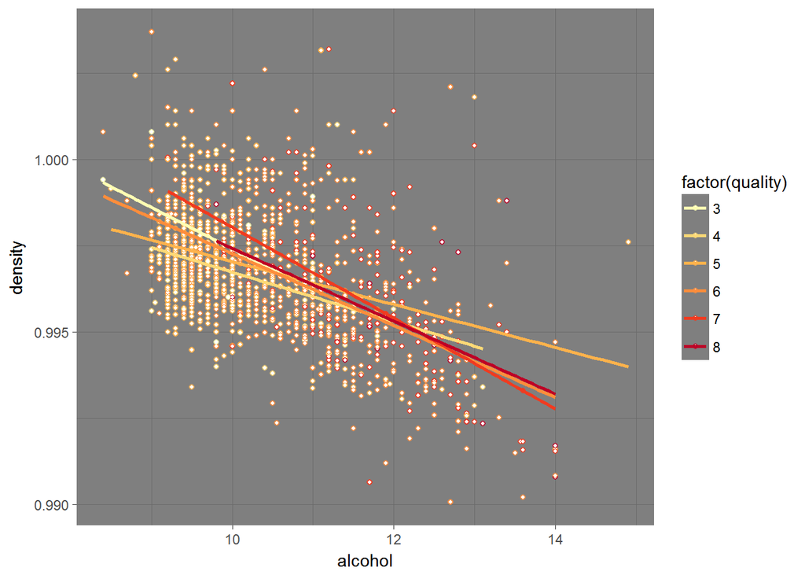

```
## $title
## [1] "Density vs Alcohol"
##
## $subtitle
## NULL
##
## attr(,"class")
## [1] "labels"
```

It is showing that as alcohol % increases the density level decreases and the good wine has less density with high alcohol % for some wine.

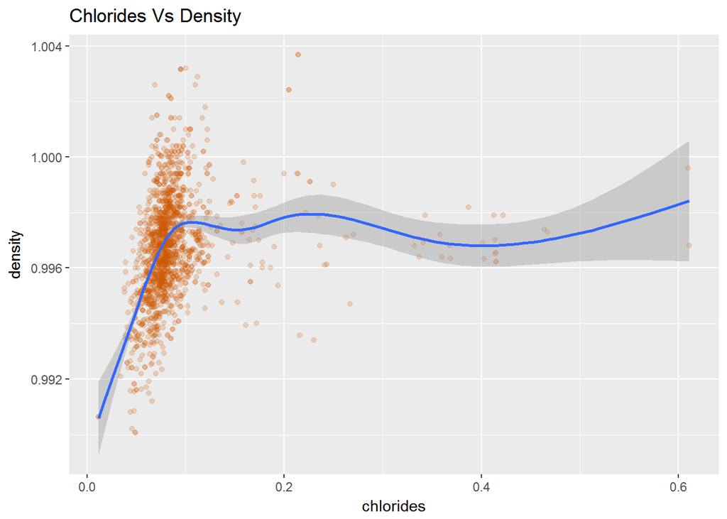

```
##
##  Pearson's product-moment correlation
##
## data:  chlorides and density
## t = 8.1842, df = 1597, p-value = 5.541e-16
## alternative hypothesis: true correlation is not equal to 0
## 95 percent confidence interval:
##  0.1531171 0.2472220
## sample estimates:
##       cor
## 0.2006323
```

```
## [1] "summary"
```

```
##    Min. 1st Qu.  Median    Mean 3rd Qu.    Max.
## 0.01200 0.07000 0.07900 0.08747 0.09000 0.61100
```

The chlorides for the wine has very less with a density below 1 and above 0.992

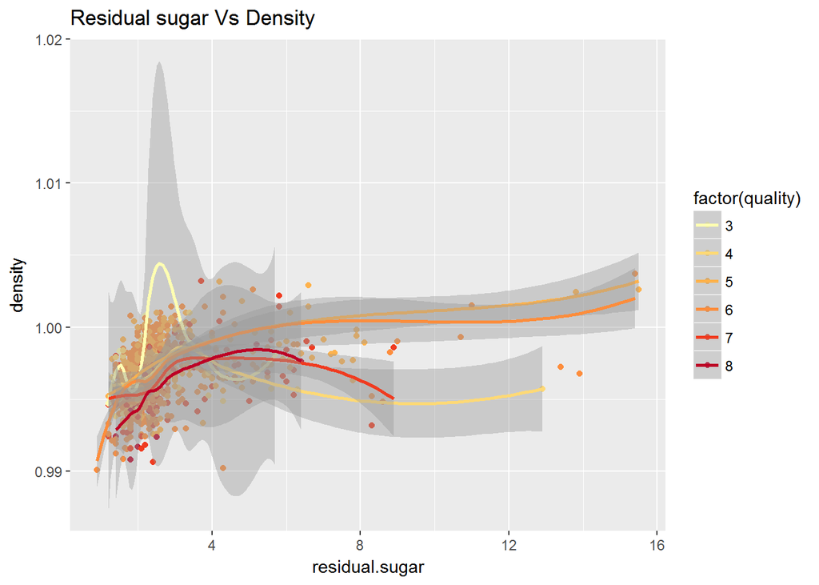

```
##
##  Pearson's product-moment correlation
##
## data:  residual.sugar and density
## t = 15.189, df = 1597, p-value < 2.2e-16
## alternative hypothesis: true correlation is not equal to 0
## 95 percent confidence interval:
##  0.3116908 0.3973835
## sample estimates:
##       cor
## 0.3552834
```

```
## [1] "summarty of residual sugar"
```

```
##    Min. 1st Qu.  Median    Mean 3rd Qu.    Max.
##   0.900   1.900   2.200   2.539   2.600  15.500
```

It showing that the highest residual suagr is 15.5 but there large varience between 3rd quardrant and maximum.

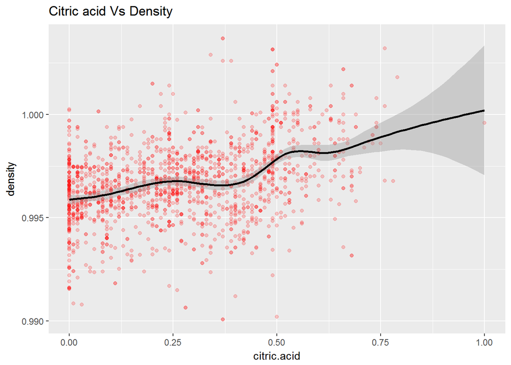

```
##
##  Pearson's product-moment correlation
##
## data:  citric.acid and density
## t = 15.665, df = 1597, p-value < 2.2e-16
## alternative hypothesis: true correlation is not equal to 0
## 95 percent confidence interval:
##  0.3216809 0.4066925
## sample estimates:
##       cor
## 0.3649472
```

```
## [1] "summary of citric acid comparing with density"
```

```
##    Min. 1st Qu.  Median    Mean 3rd Qu.    Max.
##   0.000   0.090   0.260   0.271   0.420   1.000
```

we can see a very intresting plot here that the citric acid is citric acid is slightly increased with the density.

**Exploration of acid variables**

The pH is a value shows the acidity level of wine.

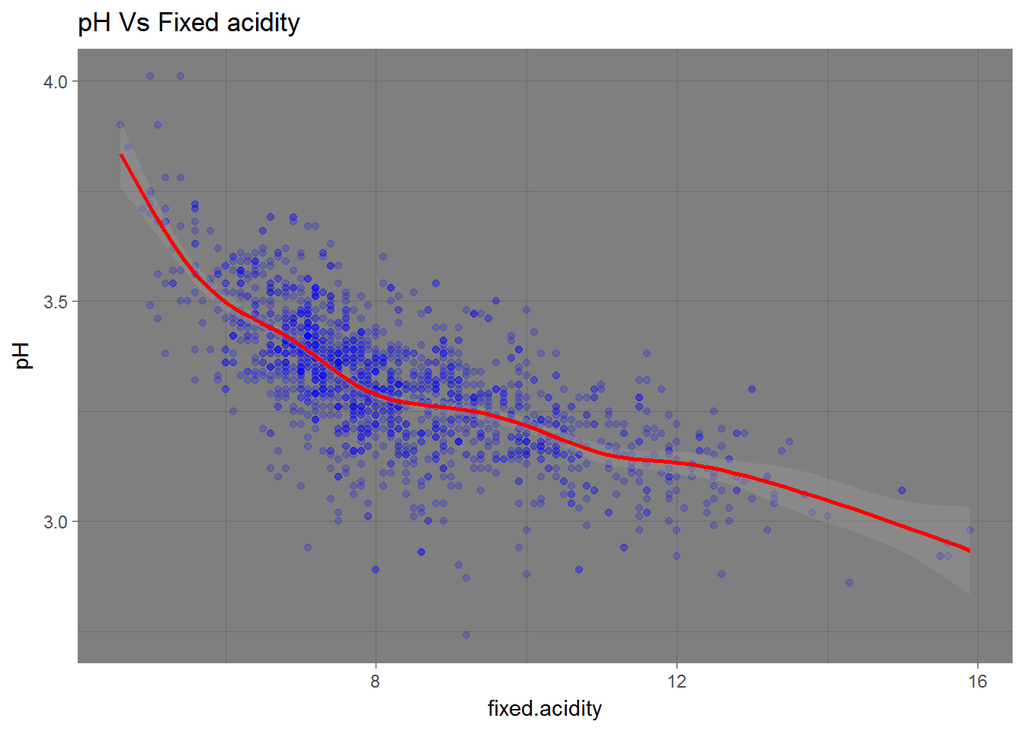

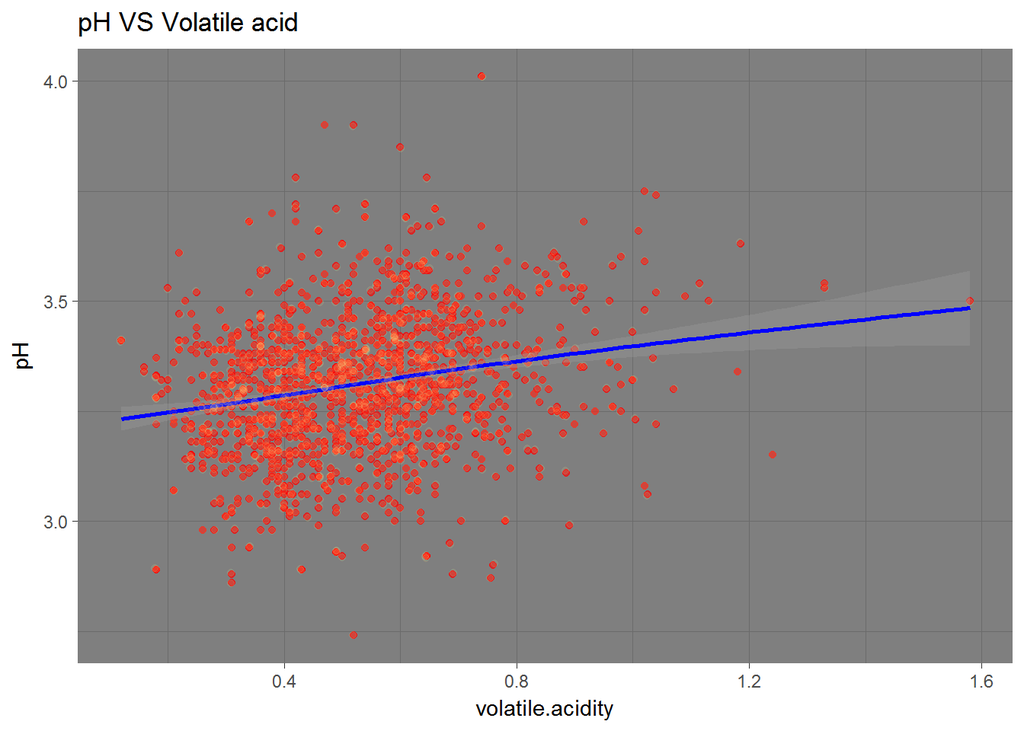

```
##
##  Pearson's product-moment correlation
##
## data:  volatile.acidity and pH
## t = 9.659, df = 1597, p-value < 2.2e-16
## alternative hypothesis: true correlation is not equal to 0
## 95 percent confidence interval:
##  0.1880823 0.2807254
## sample estimates:
##       cor
## 0.2349373
```

volatile acidity is positively recating with the pH.

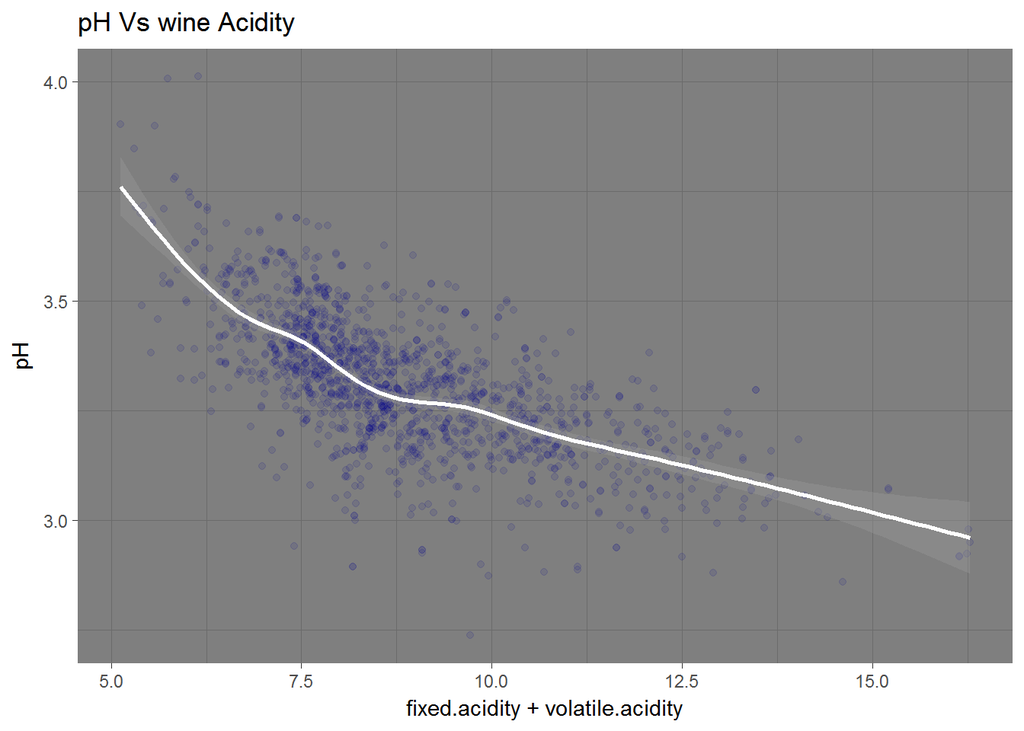

```
##
##  Pearson's product-moment correlation
##
## data:  fixed.acidity + volatile.acidity and pH
## t = -36.376, df = 1597, p-value < 2.2e-16
## alternative hypothesis: true correlation is not equal to 0
## 95 percent confidence interval:
##  -0.6990929 -0.6454169
## sample estimates:
##        cor
## -0.6731405
```

Comparing to volatile acidity the sum of both acids showing us negative corelation with pH value.

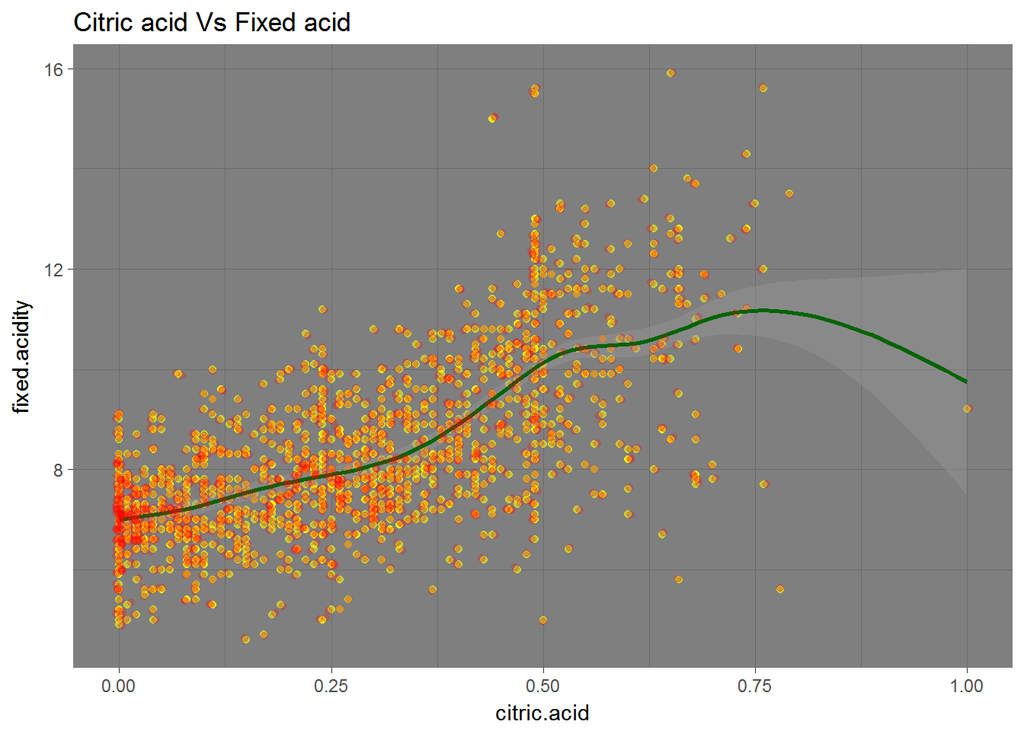

```
##
##  Pearson's product-moment correlation
##
## data:  citric.acid and fixed.acidity
## t = 36.234, df = 1597, p-value < 2.2e-16
## alternative hypothesis: true correlation is not equal to 0
## 95 percent confidence interval:
##  0.6438839 0.6977493
## sample estimates:
##       cor
## 0.6717034
```

we can see a rapid growth in a plot until to some end but a outlier on citric acid made it to drop a bit down.

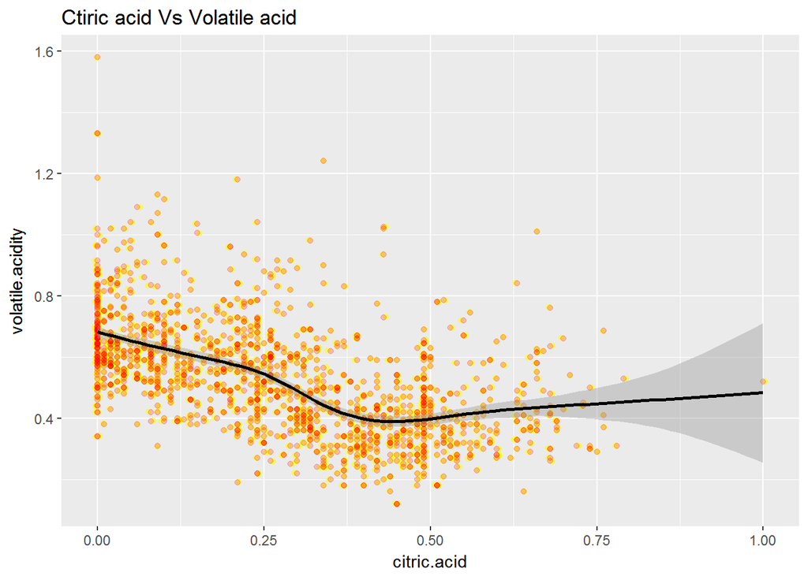

By comparing the citic acid with fixed and volatile acidities it can be konwn that volatile acid is having rapid decrease but the fixed acid has growth. so, it says that the taoal acidic nature of wine is trying to keep in equilbrium state.

**Exploring the the quality of wine with other variables**

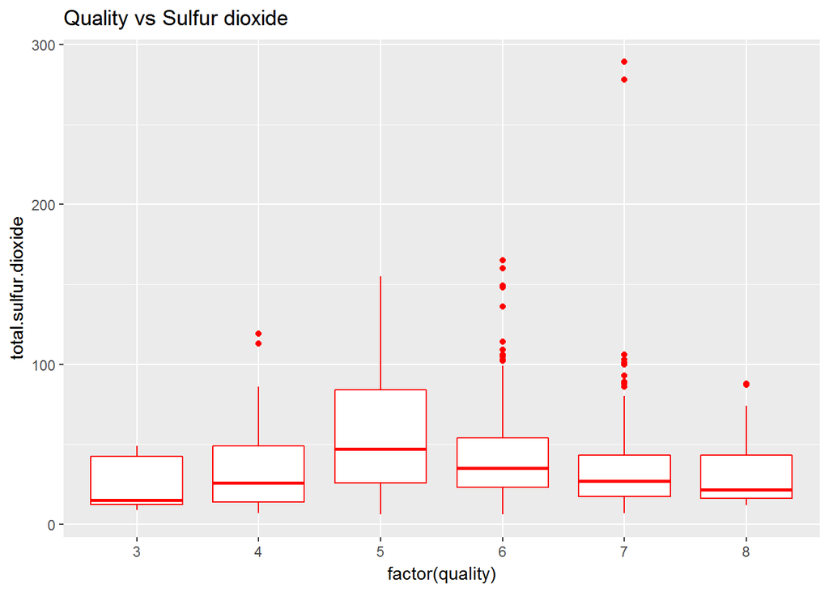

The sulfur dioxide is get known by the smell of wine here in the box plot it is clearly showing that the quality of wines with 5 rating has more smell and taste then others.

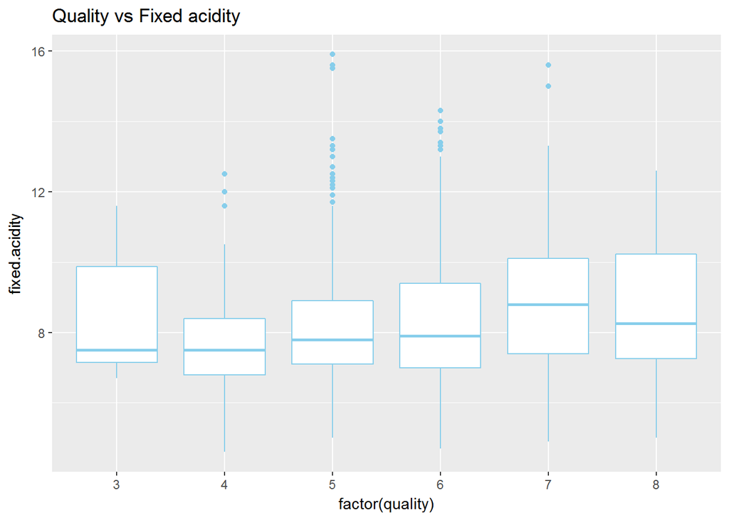

```
##
##  Pearson's product-moment correlation
##
## data:  fixed.acidity and quality
## t = 4.996, df = 1597, p-value = 6.496e-07
## alternative hypothesis: true correlation is not equal to 0
## 95 percent confidence interval:
##  0.07548957 0.17202667
## sample estimates:
##       cor
## 0.1240516
```

The fixed acidity in the wine is used to do not ecvaporate the wine easily, so, the countries were the high temperatures they try to keep the fixed acidity more and it is almost same for all the above quality wines given above there is a little varience between them.

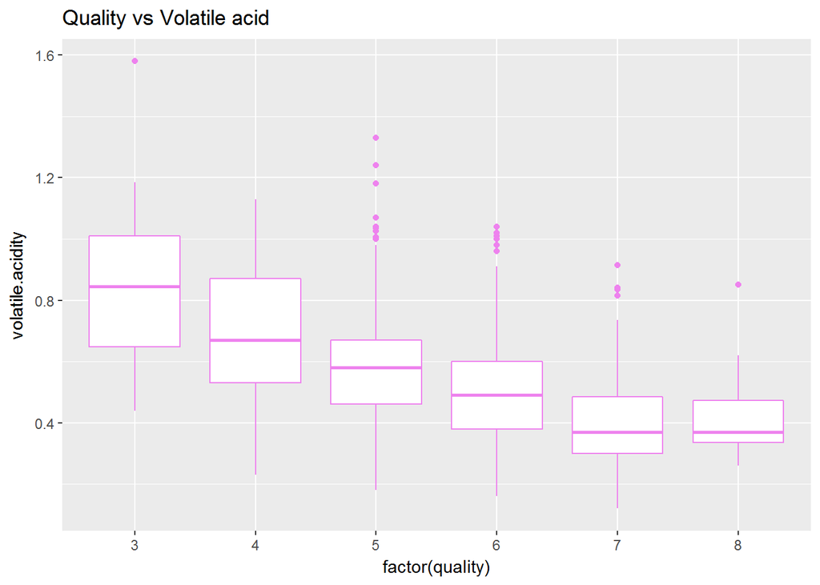

```
##
##  Pearson's product-moment correlation
##
## data:  volatile.acidity and quality
## t = -16.954, df = 1597, p-value < 2.2e-16
## alternative hypothesis: true correlation is not equal to 0
## 95 percent confidence interval:
##  -0.4313210 -0.3482032
## sample estimates:
##        cor
## -0.3905578
```

As the volatile acid nature increase the taste of wine changes as venigar so, for as the quality increases the volatile acid nature decreased.

[figure not shown]

```
##
##  Pearson's product-moment correlation
##
## data:  chlorides and quality
## t = -5.1948, df = 1597, p-value = 2.313e-07
## alternative hypothesis: true correlation is not equal to 0
## 95 percent confidence interval:
##  -0.17681041 -0.08039344
## sample estimates:
##        cor
## -0.1289066
```

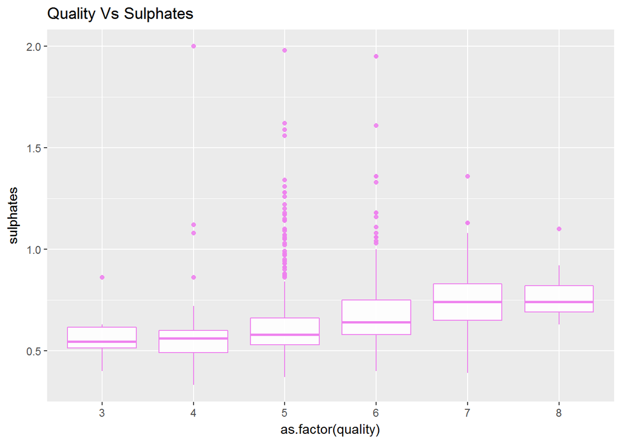

```
##
##  Pearson's product-moment correlation
##
## data:  sulphates and quality
## t = 10.38, df = 1597, p-value < 2.2e-16
## alternative hypothesis: true correlation is not equal to 0
## 95 percent confidence interval:
##  0.2049011 0.2967610
## sample estimates:
##       cor
## 0.2513971
```

The sulpahates are used to maintain a s02 gas level in the wine and its act like a antioxidant.

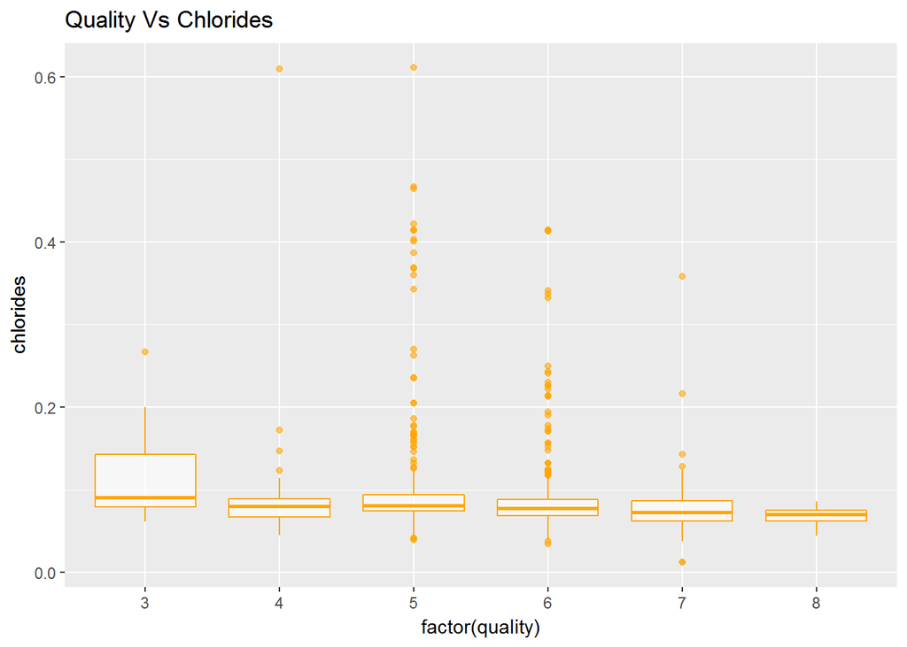

The chlorides add salt nature to the wines so, for the good quality wines have less quantity of chlorides.

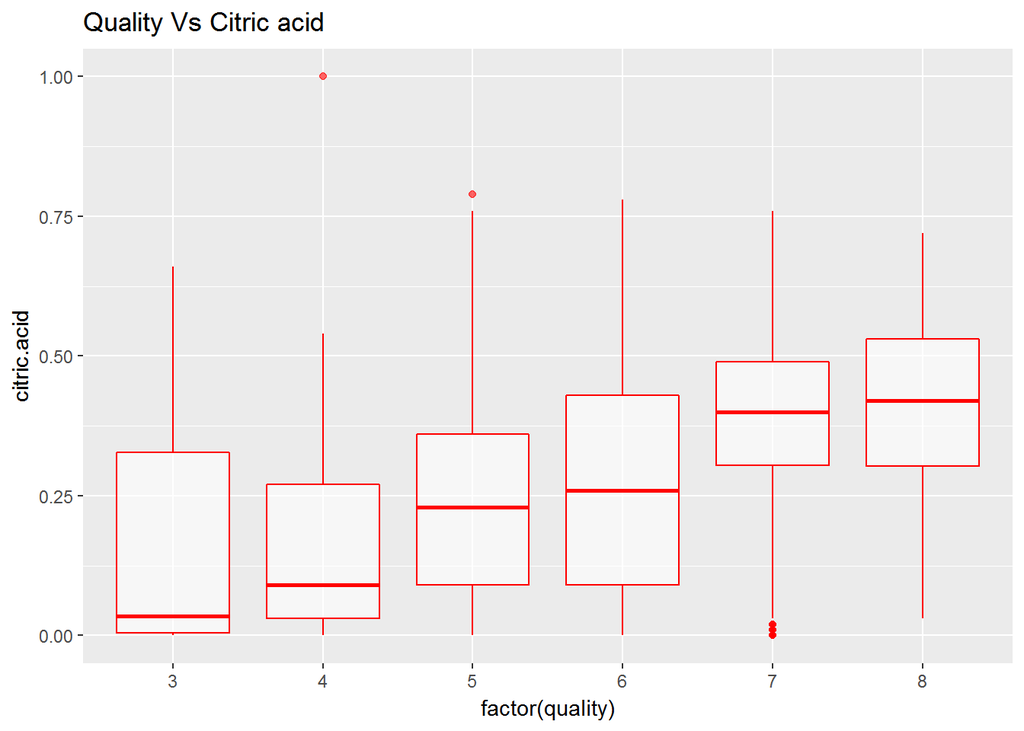

In the real life the citric acid is used to keep the wine fresh so, for the good quality of wines have high rate of citric acid but in small quantites.

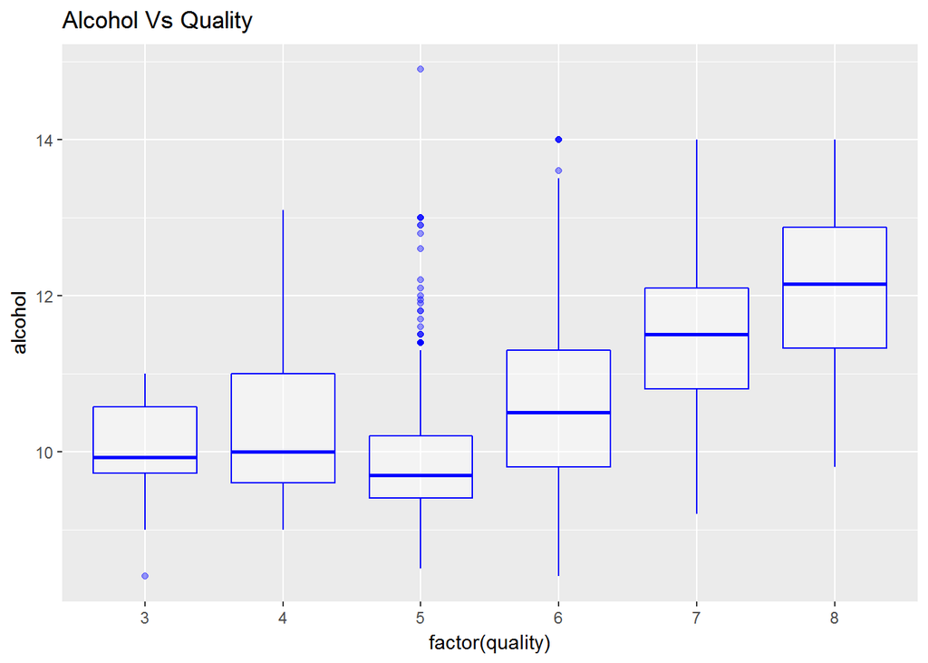

```
##
##  Pearson's product-moment correlation
##
## data:  alcohol and quality
## t = 21.639, df = 1597, p-value < 2.2e-16
## alternative hypothesis: true correlation is not equal to 0
## 95 percent confidence interval:
##  0.4373540 0.5132081
## sample estimates:
##       cor
## 0.4761663
```

Here in the given data the alcohol is goven in % and as usually the good quality of wine having higher level of alcohol.

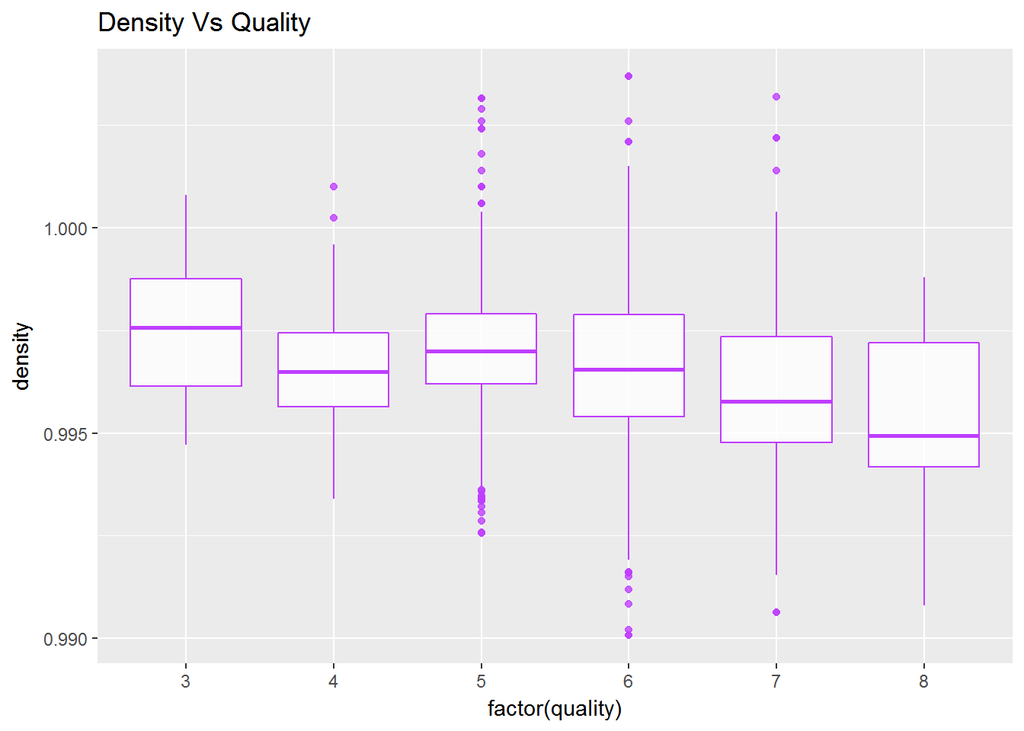

```
##
##  Pearson's product-moment correlation
##
## data:  density and quality
## t = -7.0997, df = 1597, p-value = 1.875e-12
## alternative hypothesis: true correlation is not equal to 0
## 95 percent confidence interval:
##  -0.2220365 -0.1269870
## sample estimates:
##        cor
## -0.1749192
```

Density is the water quantity that is maintained depending on the alcohol and the sugar level of the wine most of the time they try to balance the things here.